# Bipartite - Why order of species matters?

Valentin Stefan

7/21/2021

```r
library(bipartite)
```

Below is the usual `Safariland` web that comes with the `bipartite` package. The species names come in a particular order. We will see that if we alter that order, we can get differences in some network metrics and this seems unexpected for me. **Why would the order of the species matter and then what is the correct order?**

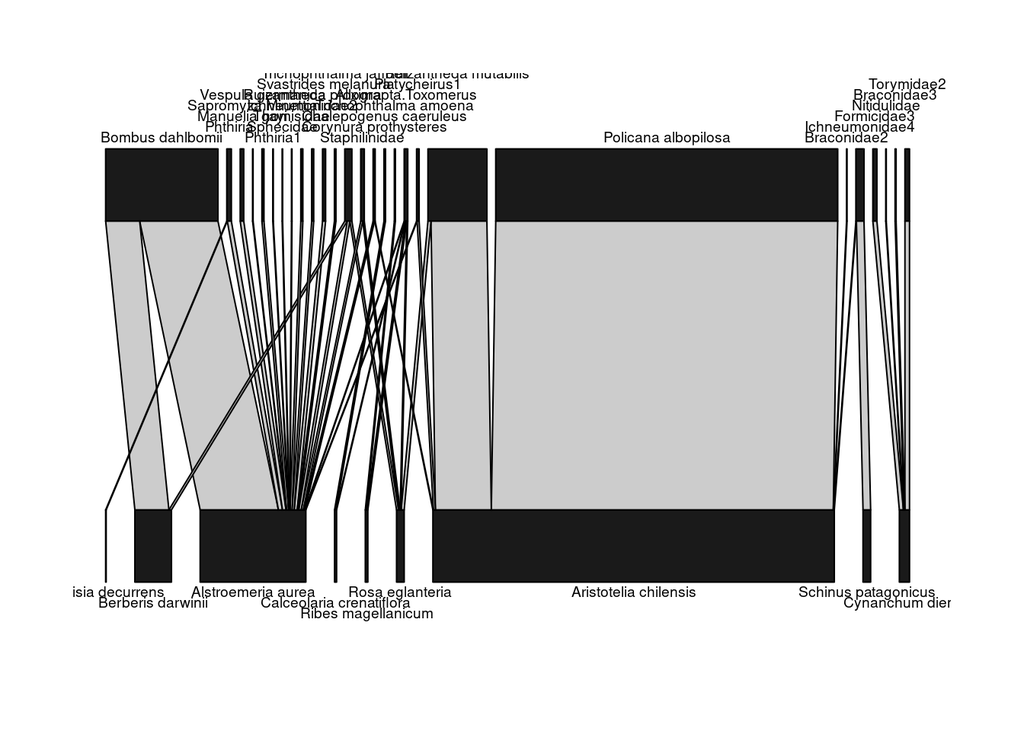

```r
set.seed(1)
plotweb(Safariland)
```

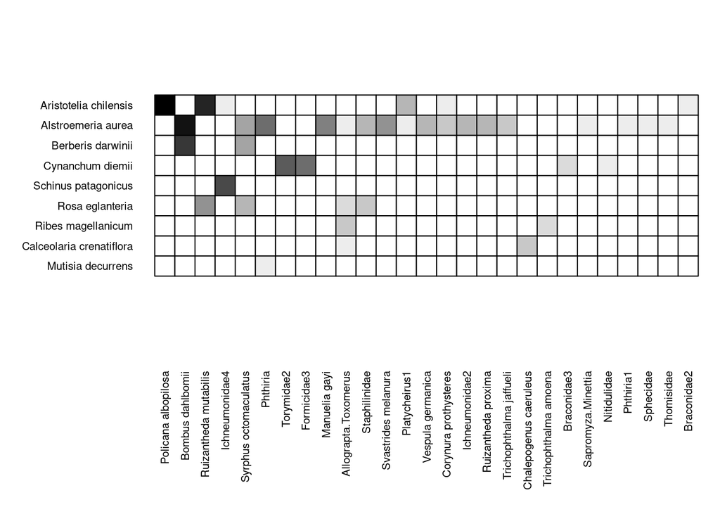

```r
set.seed(1)
visweb(Safariland)
```

# Network level metrics

These are the network metrics that one can compute:

```r
set.seed(1)
net_1 <- networklevel(web = Safariland)
```

If we shuffle the insect species names in `Safariland`, we get differences in some network metrics. We do not alter the structure of the network, the abundance information stays unchanged, we just randomly input data in a different order (could be whatever order we typed in the species in the Excel file).

```r
# Shuffle columns to simulate whatever input order from an Excel file
set.seed(1)
Safariland_2 <- Safariland[, sample(colnames(Safariland))]
```

First, we plot the shuffled web to see that the order is changed but not abundance information:

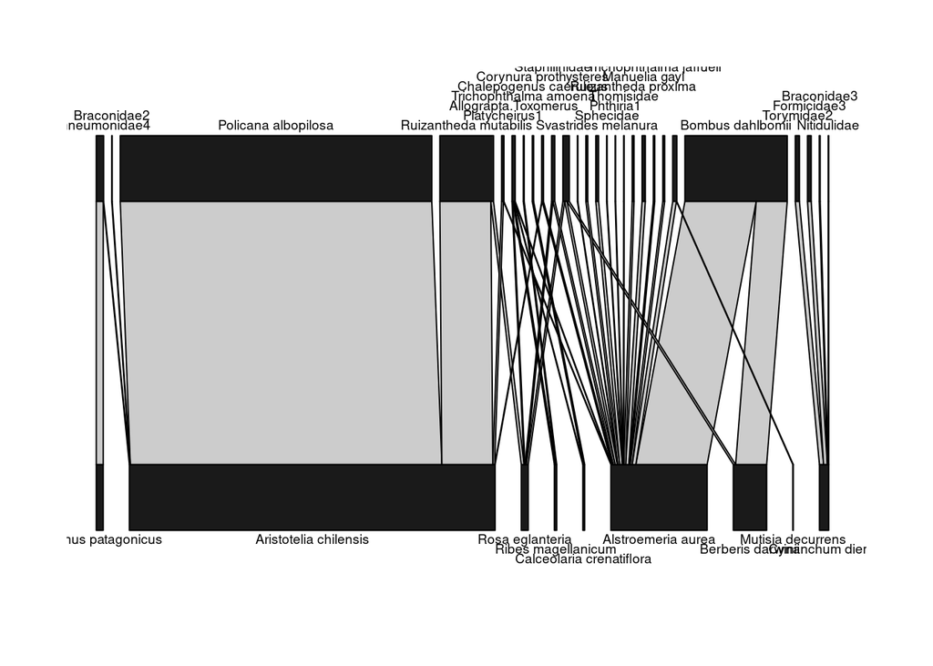

```r
set.seed(1)
plotweb(Safariland_2)
```

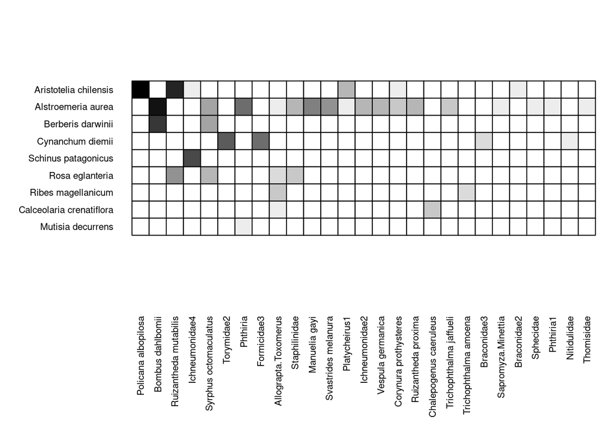

```r
set.seed(1)
visweb(Safariland_2)
```

Compute again network metrics with the shuffled names:

```r
set.seed(1)
net_2 <- networklevel(web = Safariland_2)

# The two results are different!
identical(net_1, net_2)
```

```
## [1] FALSE
```

Not all metrics change, but here are the ones where differences appear:

```r
net_df <- data.frame(net_1, net_2)
net_df$dif <- net_df$net_1 - net_df$net_2
net_df[net_df$dif != 0,]
```

```
##                          net_1      net_2           dif
## modularity Q         0.4301558  0.4304096 -0.0002537395
## nestedness          19.7469507 21.1097884 -1.3628376612
## weighted nestedness  0.3902361  0.4071116 -0.0168754937
## discrepancy.HL      21.0000000 19.0000000  2.0000000000
## extinction.slope.HL  2.4911015  2.7739199 -0.2828183462
## extinction.slope.LL  1.3997589  1.4837515 -0.0839926148
## robustness.HL        0.7091096  0.7264022 -0.0172926460
## robustness.LL        0.5827932  0.5959190 -0.0131257670
```

Also, what if we change the order of the plant names and keep the order of the insects unaltered?

```r
# Shuffle columns
set.seed(1)
Safariland_3 <- Safariland[sample(rownames(Safariland)), ]

# Compute network metrics
set.seed(1)
net_3 <- networklevel(web = Safariland_3)

# The two results are different again!
identical(net_1, net_3)
```

```
## [1] FALSE
```

Here are the differences:

```r
net_df <- data.frame(net_1, net_3)
net_df$dif <- net_df$net_1 - net_df$net_3
net_df[net_df$dif != 0,]
```

```
##                           net_1       net_3           dif
## modularity Q         0.43015585  0.43040959 -2.537395e-04
## nestedness          19.74695075 19.91414339 -1.671926e-01
## weighted nestedness  0.39023609  0.36374136  2.649473e-02
## niche.overlap.LL     0.04794504  0.04794504 -6.938894e-18
## discrepancy.LL      16.00000000 17.00000000 -1.000000e+00
## extinction.slope.HL  2.49110150  2.44858368  4.251783e-02
## extinction.slope.LL  1.39975886  1.40106275 -1.303893e-03
## robustness.HL        0.70910955  0.70562802  3.481535e-03
## robustness.LL        0.58279325  0.58736072 -4.567469e-03
```

Order alphabetically the column names:

```r
# Sort
Safariland_4 <- Safariland[, sort(colnames(Safariland))]

# Compute network metrics
set.seed(1)
net_4 <- networklevel(web = Safariland_4)

# The two results are different again!
identical(net_1, net_4)
```

```
## [1] FALSE
```

The differences:

```r
net_df <- data.frame(net_1, net_4)
net_df$dif <- net_df$net_1 - net_df$net_4
net_df[net_df$dif != 0,]
```

```
##                                      net_1        net_4           dif
## modularity Q                     0.4301558    0.4304096 -0.0002537395
## nestedness                      19.7469507   21.0863251 -1.3393743284
## weighted nestedness              0.3902361    0.4206293 -0.0303931919
## togetherness.HL                  0.1606838    0.1785375 -0.0178537512
## discrepancy.HL                  21.0000000   22.0000000 -1.0000000000
## extinction.slope.HL              2.4911015    2.5638979 -0.0727963518
## extinction.slope.LL              1.3997589    1.4766188 -0.0768599732
## robustness.HL                    0.7091096    0.7125204 -0.0034108041
## robustness.LL                    0.5827932    0.5948565 -0.0120632675
## functional.complementarity.HL 1683.8042072 1683.7006539  0.1035533906
```

# Species level metrics

Same thing can happen also for species level metrics:

```r
set.seed(1)
sp_1 <- specieslevel(web = Safariland)
sp_2 <- specieslevel(web = Safariland_4)
identical(sp_1, sp_2)
```

```
## [1] FALSE
```

```r
all.equal(sp_1, sp_2)
```

```
##  [1] "Component \"higher level\": Attributes: < Component \"row.names\": 24 string mismatches >"
##  [2] "Component \"higher level\": Component \"degree\": Mean relative difference: 0.8571429"
##  [3] "Component \"higher level\": Component \"normalised.degree\": Mean relative difference: 0.8571429"
##  [4] "Component \"higher level\": Component \"species.strength\": Mean relative difference: 0.8444733"
##  [5] "Component \"higher level\": Component \"interaction.push.pull\": Mean relative difference: 0.5086197"
##  [6] "Component \"higher level\": Component \"nestedrank\": Mean relative difference: 0.5867508"
##  [7] "Component \"higher level\": Component \"PDI\": Mean relative difference: 0.08195228"
##  [8] "Component \"higher level\": Component \"resource.range\": Mean relative difference: 0.2068966"
##  [9] "Component \"higher level\": Component \"species.specificity.index\": Mean relative difference: 0.2369427"
## [10] "Component \"higher level\": Component \"PSI\": Mean relative difference: 1.085562"
## [11] "Component \"higher level\": Component \"node.specialisation.index.NSI\": Mean relative difference: 0.306914"
## [12] "Component \"higher level\": Component \"betweenness\": Mean relative difference: 1.953846"
## [13] "Component \"higher level\": Component \"weighted.betweenness\": Mean relative difference: 2"
## [14] "Component \"higher level\": Component \"closeness\": Mean relative difference: 0.5891117"
## [15] "Component \"higher level\": Component \"weighted.closeness\": Mean relative difference: 1.065834"
## [16] "Component \"higher level\": Component \"partner.diversity\": Mean relative difference: 1.700466"
## [17] "Component \"higher level\": Component \"effective.partners\": Mean relative difference: 0.6356518"
## [18] "Component \"higher level\": Component \"proportional.generality\": Mean relative difference: 0.6356518"
## [19] "Component \"higher level\": Component \"proportional.similarity\": Mean relative difference: 1.144186"
## [20] "Component \"higher level\": Component \"d\": Mean relative difference: 0.7500356"
```